# preprocess PanCancer nanostring data

Mingming Zhang & Amrit Singh

December 22, 2025

# Purpose of this analysis

1. Import NanoString nCounter data
2. Perform quality control assessment based on NanoString Data Analysis Guidelines
3. Normalize and filter expression data
4. Generate final analysis-ready datasets

## Setup: Libraries and utilities

# 1) Import NanoString data

## 1a. Read RCC files and merge datasets

```r
filePaths <- sapply(c("20150703_asingh - pancancer MAXset A_RCC",
         "20150709_setB max fov - ykw n amrit_RCC",
         "20150709_Set3-C-AMRIT-KYW-MAX_RCC"), function(file){
           here::here("data", "rawdata", "nanoString", file)
         })


#----------------------------------------------
# import RC files and compile into a dataframe
#----------------------------------------------
setName <- paste("Set", 1:length(filePaths))
date <- c("2015-07-03","2015-07-03","2015-07-03")
DatList <- list()
for(h in 1 : length(filePaths)){
  files <- list.files(filePaths[h], full.names = TRUE)
  dat <- lapply(as.list(files), function(i){
          rcc_to_dat(fileName = i)
          }) %>% do.call(rbind, .)
  dat$Set <- setName[h]
  dat$Date <- date[h]
  DatList[[h]] <- dat
}
Dat <- do.call(rbind, DatList)
## Fix gene Names for some genes
Dat$Name[Dat$Accession == "NM_014512.1"] <- "KIR2DS1" ## KIR_Activating_Subgroup_2
Dat$Name[Dat$Accession == "NM_014218.2"] <- "KIR2DL1" ## KIR_Inhibiting_Subgroup_1
Dat$Name[Dat$Accession == "NM_001083539.1"] <- "KIR3DS1" ## KIR_Activating_Subgroup_1
Dat$Name[Dat$Accession == "NM_014511.3"] <- "KIR2DL3" ## KIR_Inhibiting_Subgroup_2
Dat$Name[Dat$Name == "IL8"] <- "CXCL8"
write.csv(Dat, here::here("data", "preprocessedData", "cleanedRawData_panCancerDiscovery.csv"))
```

```r
sampleMap <- c(paste0("E", 1:36))
data <- read.csv(here::here("data", "preprocessedData", "cleanedRawData_panCancerDiscovery.csv"), row.names = 1)
names(sampleMap) <- unique(data$fileName)
data$Sample <- sampleMap[as.character(data$fileName)]
write.csv(data, here::here("data", "preprocessedData", "cleanedRawData_panCancerDiscovery.csv"))
```

## 1c. Sample mapping and demographics

```r
demo <- readRDS(here::here("data", "preprocessedData", "allsitesDemo.rds"))
rownames(demo) <- paste(demo$concealedID, demo$Time, sep = "_")
demoPre0 <- demo[!is.na(demo$EorV_number) , ]
rownames(demoPre0) <- demoPre0$EorV_number
dim(demoPre0)
```

```
## [1] 111  35
```

```r
demoPre <- demoPre0[sampleMap, ]
```

# 2) Quality Control / Quality Assessment

## 2a. Fields of View (FOV)

- each lane is imaged in discrete units called FOVs
- FOV Count = # of FOVs for which imaging was attempted
- FOV Counted = # of FOVs sucessfully imaged
- Causes of discrepancy between FOV Count & FOV Counted: optical issues such as bubbles or insufficient oiling of cartridge
- *Imaging QC (nSolver default)*: Flag lanes when percent FOV registration is less than 75

## 2b. Binding Density

```r
qc <- data %>% mutate(FOVratio = FovCounted_Lane_Attributes/FovCount_Lane_Attributes) %>%
        dplyr::select(FOVratio, BindingDensity = BindingDensity_Lane_Attributes, Sample, Set, ID_Lane_Attributes) %>%
        gather(QCVar, QCmetrics, -c(Sample, Set, ID_Lane_Attributes)) %>% group_by(Sample, QCVar, Set) %>%
  #distinct(Sample, Set, ID_Lane_Attributes) %>%
  mutate(Sample_Lane = paste(Sample, ID_Lane_Attributes, sep="_"))
qc$Sample_Lane <- factor(qc$Sample_Lane, levels = unique(qc$Sample_Lane))

qc %>% ungroup %>% dplyr::group_by(QCVar) %>%
  dplyr::summarise(min = min(QCmetrics), max = max(QCmetrics))
```

```
## # A tibble: 2 × 3
##   QCVar            min   max
##   <chr>          <dbl> <dbl>
## 1 BindingDensity 0.41  1.17
## 2 FOVratio       0.941 0.989
```

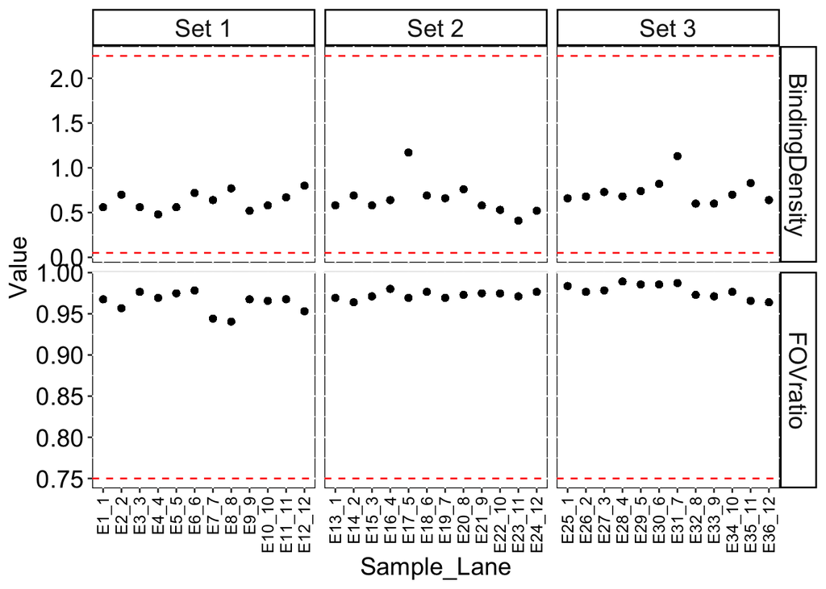

FOV ratio and Binding density.

```r
hline.data <- data.frame(yint = c(0.75, 0.05, 2.25),
                         QCVar = c("FOVratio", rep("BindingDensity", 2)))
ggplot(data = qc, aes(x = Sample_Lane, y = QCmetrics)) + geom_point() +
  facet_grid(QCVar~Set, scale = "free") +
  geom_hline(data = hline.data, aes(yintercept = yint), lty = 2, col = "red") +
  customTheme(sizeStripFont=15, xAngle=90, hjust = 1, vjust = 0.5, xSize=10, ySize=15, xAxisSize=15, yAxisSize=15) + ylab("Value")
```

> all samples pass Imaging QC and Binding Density QC.

## 2c. Internal Controls

- nanoString uses External RNA Control Consortium (ERCC) controls for both positive and negative controls
- ERRC is a group that develops RNA transcripts not homologous to known organisms, generate consistent results in gene expression data –> used to assess technical performance in gene expression assays.

### 2d. Positive Controls

- For each sample, there are six positive controls (POS_A-POS_F) corresponding to six different concentrations in the 30 ul hybridzation: 128fM, 32fM, 8fM, 2fM, 0.5fM, and 0.125fM.
- *Positive Control Linearity QC*: Flag lanes when Positive Control $R^2$ value is less than 0.9

```r
posConc <- c(128, 32, 8, 2, 0.5, 0.125)
names(posConc) <- paste0(paste("POS", LETTERS[1:6], sep = "_"), paste0("(", posConc, ")"))
posDat <- data %>% filter(CodeClass == "Positive_Code_Summary") %>%
  mutate(posConc = posConc[as.character(Name)],
         Sample_Lane = paste(Sample, ID_Lane_Attributes, sep="_"))

mods <- posDat %>%
  group_by(ID_Lane_Attributes, Set) %>% do(., r2 = summary(lm(Count ~ posConc, data = .))$r.squared)
r.squared <- data.frame(ID_Lane_Attributes = mods$ID_Lane_Attributes, R2 = round(unlist(mods$r2), 2),
                        Set = mods$Set)
r.squared$x <- 20
r.squared$y <- 100

all(mods$r2 > 0.99)
```

```
## [1] TRUE
```

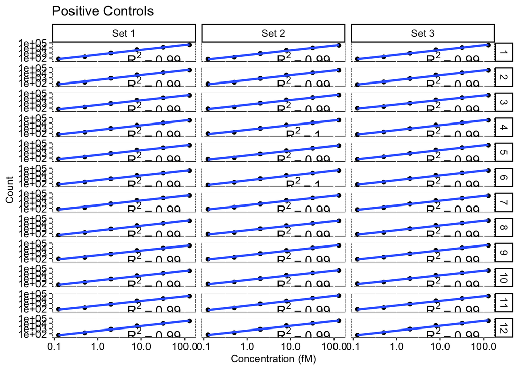

Positive Control Linearity QC.

```r
## order E samples from 1-36
posDat$Sample_Lane <- factor(posDat$Sample_Lane,
                             levels = unique(posDat$Sample_Lane))

ggplot(posDat, aes(x = posConc, y = Count)) + geom_point() +
  facet_grid(ID_Lane_Attributes~Set) +
  scale_x_log10() + scale_y_log10() +
  stat_smooth(method = "lm") +
  geom_text(aes(x, y, label = paste0("R^2 ==", R2), size = 0.1),
            data = r.squared, parse = TRUE) +
  theme(legend.position = "none") +
  xlab("Concentration (fM)") +
  ggtitle("Positive Controls") +
  customTheme(sizeStripFont=10, xAngle=0, hjust=0.5, vjust=1, xSize=10, ySize=10, xAxisSize=10, yAxisSize=10)
```

> all samples pass Positive Control Linearity: range = QC 0.9901702, 0.99516

### 2e. Negative Controls

- estimate systemic background counts within any single hybridization reaction.
- *Positive Control Limit of Detection QC*: Flag lanes when 0.5fM positive control is less than or equal to 2 standard deviations above the mean of the negative controls.

```r
negSD <- data %>% dplyr::filter(CodeClass == "Negative_Code_Summary") %>% group_by(fileName, Set, Sample) %>% dplyr::summarise(negThres = mean(Count)+2*sd(Count))
pos0.5 = posDat %>% filter(posConc == 0.5)
all(levels(negSD$Sample) == levels(pos0.5$Sample))   # TRUE
```

```
## [1] TRUE
```

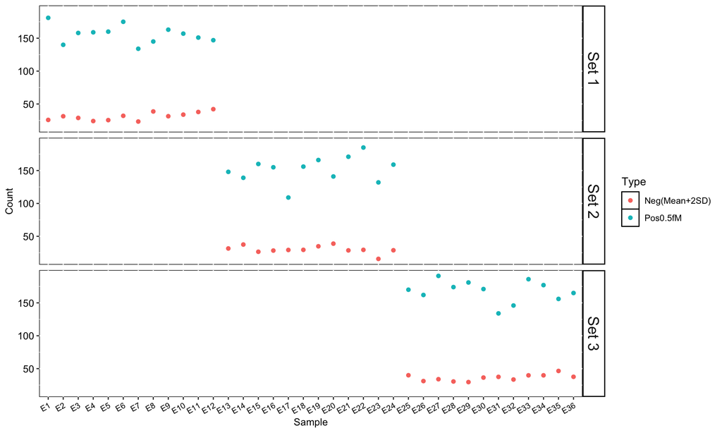

Positive Control Limit of Detection QC.

```r
negPos <- as.data.frame(rbind(negSD[, c("Sample", "Set", "negThres")], setNames(pos0.5[, c("Sample", "Set", "Count")], c("Sample", "Set", "negThres"))))
negPos$Type = rep(c("Neg(Mean+2SD)","Pos0.5fM"), each=nrow(negSD))
negPos$Sample <- factor(negPos$Sample, levels = unique(negPos$Sample)[order(as.numeric(gsub("E","",unique(negPos$Sample))))])

ggplot(negPos, aes(x = Sample, y = negThres, color = Type)) + geom_point() + ylab("Count") + customTheme(sizeStripFont=15, xAngle=30, hjust = 1, vjust = 1, xSize=8, ySize=10, xAxisSize=10, yAxisSize=10) + facet_grid(Set~.)
```

> all samples are pass the Positive control limit of detection QC

# 3) Normalization

## 3a. Positive Control Normalization

- Positive controls normalize all platform associated sources of variation (e.g. automated purfication, hybridization conditions etc.)
- does not account for sample input between technical and biological replicates
- Positive Control Scaling factor QC: If the positive control scaling factor is outside a range of 0.3-3, –> may indicate significant under-performance of a lane

```r
#str(posDat)

posNF <- posDat %>% group_by(Sample) %>%
  dplyr::summarise(posGeoMean = geometric.mean(Count), fileName = unique(fileName)) %>%
  mutate(posNF = mean(posGeoMean)/posGeoMean)
range(posNF$posNF)
```

```
## [1] 0.8437908 1.2326545
```

```r
all(posNF$posNF<3 & posNF$posNF > 0.3)
```

```
## [1] TRUE
```

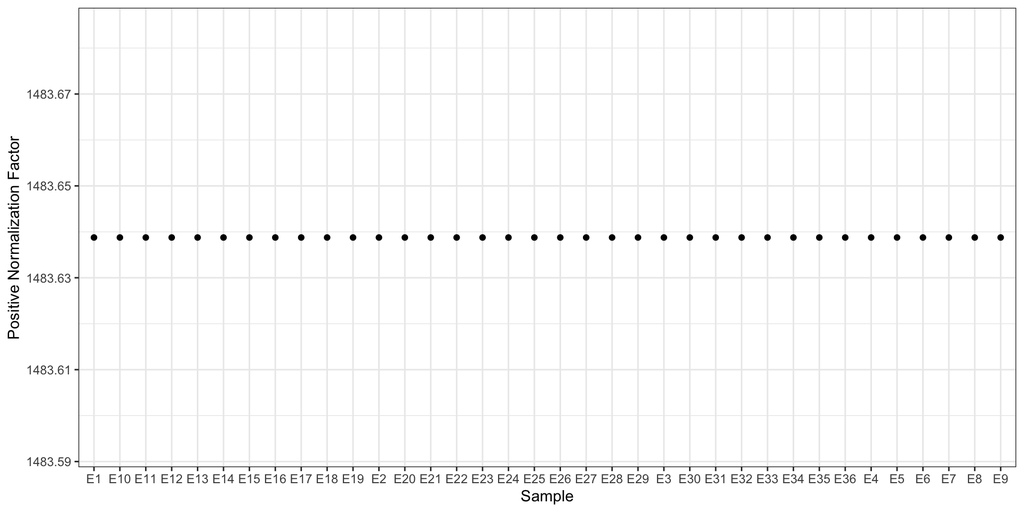

```r
dataNorm <- full_join(data, posNF, by = "fileName") %>% mutate(posNorm = Count*posNF)

# check if the sum of the positive controls is the same for each assay
dataNorm %>% group_by(fileName) %>% filter(CodeClass == "Positive_Code_Summary") %>% dplyr::summarise(sumPosSample = geometric.mean(posNorm), Sample = unique(Sample.x), Set = unique(Set)) %>%
  dplyr::select(Sample, sumPosSample) %>%
  ggplot(aes(x = Sample, y = sumPosSample)) + geom_point() + theme_bw() +
  ylab("Positive Normalization Factor")
```

## 3b. Correlation between replicates using endogenous genes only

```r
all(dataNorm$Sample.x == dataNorm$Sample.y)
```

```
## [1] TRUE
```

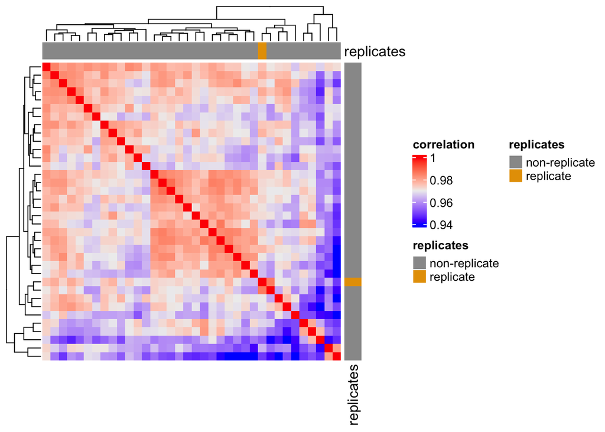

```r
expDat0 <- dataNorm %>% filter(CodeClass == "Endogenous_Code_Summary") %>%
           dplyr::select(Name, posNorm, Sample.x) %>%
           tidyr::spread(Name, posNorm)
expDat <- expDat0[, -1]
rownames(expDat) <- expDat0$Sample.x

## LST_026
samples <- as.character(demoPre$MST_LST_numbers)[rownames(demoPre) %in% rownames(expDat)]
names(samples) <- as.character(rownames(demoPre)[rownames(demoPre) %in% rownames(expDat)])
Y <- as.data.frame(log2(t(expDat[names(samples[grep("L_ST_026", samples)]),])))
colnames(Y) <- paste(colnames(Y), as.character(demoPre[colnames(Y), "AIC_YMD"]), sep=".")

a = expDat
a[a==0] <- 1
a <- log2(a)
b = cor(t(a))
replicates <- samples[rownames(b)]
rownames(b) <- colnames(b) <- NULL
replicates[replicates == "L_ST_026"] <- "replicate"
replicates[replicates != "replicate"] <- "non-replicate"
row_ha <- rowAnnotation(replicates = replicates, col=list(replicates = c("replicate"="#E69F00", "non-replicate"="#999999")))
col_ha <- columnAnnotation(replicates = replicates, col=list(replicates = c("replicate"="#E69F00", "non-replicate"="#999999")))
Heatmap(b, right_annotation = row_ha, top_annotation = col_ha, name = "correlation")
```

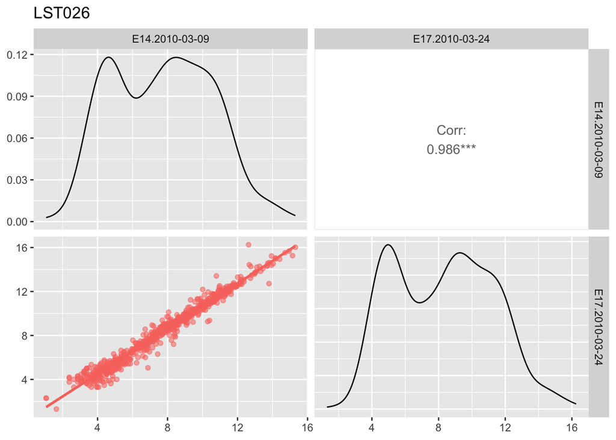

```r
#pdf(paste0(WhereAmI, "results/Figures/Fig.S1.pdf"), height = 8, width = 8)
ggpairs(Y, mapping = aes(alpha = 0.5),
  title = "LST026",
  lower = list(
    continuous = "smooth",
    combo = "facetdensity",
    mapping = aes(color = "blue")))
```

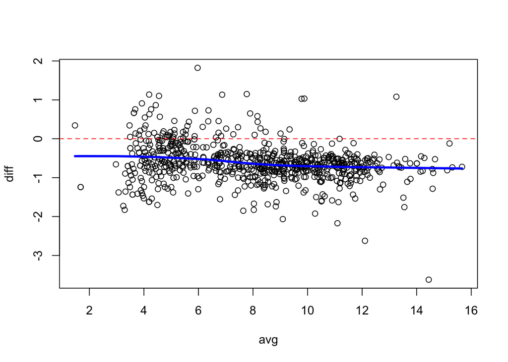

```r
#dev.off()

## MA plot
diff <- Y[, "E14.2010-03-09"] - Y[, "E17.2010-03-24"]
avg <- (Y[, "E14.2010-03-09"] + Y[, "E17.2010-03-24"])/2

plot(diff ~ avg)
lines(lowess(diff ~ avg), col = "blue", lwd = 3)
abline(h = 0, lty = 2, col = "red")
```

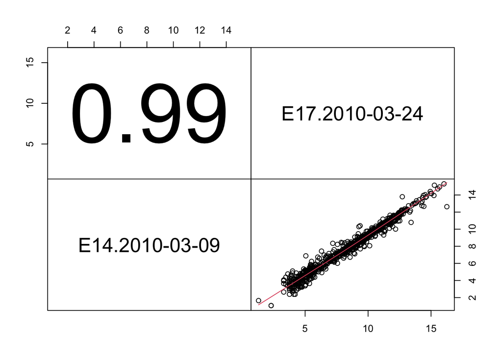

```r
## put histograms on the diagonal
panel.cor <- function(x, y, digits = 2, prefix = "", cex.cor, ...){
    par(usr = c(0, 1, 0, 1))
    r <- abs(cor(x, y))
    txt <- format(c(r, 0.123456789), digits = digits)[1]
    txt <- paste0(prefix, txt)
    if(missing(cex.cor)) cex.cor <- 0.8/strwidth(txt)
    text(0.5, 0.5, txt, cex = cex.cor * r)
}
pairs(Y, lower.panel = panel.smooth, upper.panel = panel.cor,
      gap=0, row1attop=FALSE)
```

## 3c. Principal Component Analysis using endogenous genes only LST26 (14, 17)

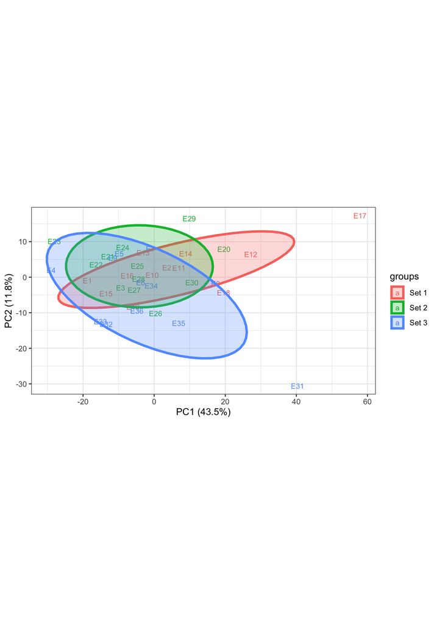

```r
group <- samples[rownames(expDat)]
group[group != "L_ST_026"] <- "other samples"
batch <- rep(c("Set 1", "Set 2", "Set 3"), each = 12)
names(batch) <- paste0("E", 1:36)
pcaDat <- prcomp(expDat, scale. = TRUE, center = TRUE)
## color replicates
ggbiplot(pcaDat, obs.scale = 1, var.scale = 1,
         group = batch,
         ellipse = T, circle = F,
         var.axes = FALSE, labels = rownames(expDat)) +
  theme_bw()
```

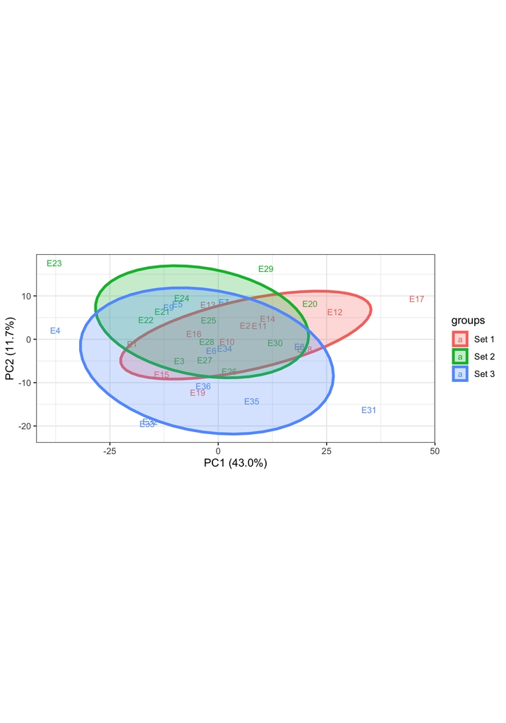

```r
pcaDat <- prcomp(a, scale. = TRUE, center = TRUE)
## color replicates
ggbiplot(pcaDat, obs.scale = 1, var.scale = 1,
         group = batch,
         ellipse = T, circle = F,
         var.axes = FALSE, labels = rownames(expDat)) +
  theme_bw()
```

## 3d. Filtering of low abundant features

```r
## remove the second replicate (L_ST_026_R1)
as.character(demoPre$UniqueID)[rownames(demoPre) %in% "E17"]
```

```
## [1] "L_ST_026_R1"
```

```r
dataNorm2 <- dataNorm %>% filter(Sample.x != "E17")

allCounts0 <- dataNorm2 %>% filter(CodeClass == "Endogenous_Code_Summary") %>%
             dplyr::select(Sample.x, Name, posNorm) %>%
             spread(Name, posNorm)
allCounts <- as.matrix(allCounts0[, -1])
rownames(allCounts) <- allCounts0$Sample

## 1) determine max of negative controls
maxNegativeCount <- dataNorm2 %>% filter(CodeClass == "Negative_Code_Summary") %>%
                     dplyr::summarize(maxNeg = max(posNorm))
maxNegativeCount
```

```
##     maxNeg
## 1 45.91899
```

```r
passThreshold <- colSums(allCounts > maxNegativeCount$maxNeg)/nrow(allCounts)
sum(passThreshold > 0) ## keep genes with at least 1 count of 35 samples > than the max value of negative controls
```

```
## [1] 600
```

```r
## 2) filter genes with all counts below the maximum value of the negative counts
dataNormEndoFiltered <- dataNorm2 %>% filter(Name %in% names(passThreshold)[passThreshold > 0]) %>%
                        mutate(Name = droplevels(factor(Name)))
dataNormHk <- filter(dataNorm2, CodeClass %in% "Housekeeping_Code_Summary")
dataNorm3 <- rbind(as.data.frame(dataNormEndoFiltered), as.data.frame(dataNormHk))
```

## 3e. House-keeping normalization

[figure not shown]

```r
hk <- filter(dataNorm3, CodeClass == "Housekeeping_Code_Summary")

## Plot house-keeping genes for 35 samples
ggplot(hk, aes(x = as.numeric(Sample.x), y = posNorm, color = Name)) + geom_point() + geom_line() +
  scale_y_log10() + customTheme(sizeStripFont=15, xAngle=0, hjust = 0.5, vjust = 0.5, xSize=10, ySize=15, xAxisSize=15, yAxisSize=15) + xlab("35 samples") + ylab("Counts")
```

```r
hkDat0 <- hk %>% dplyr::select(Sample.x, Name, posNorm) %>% spread(Sample.x, posNorm)
hkDat <- as.matrix(hkDat0[, -c(1)])
#hkDat[hkDat < 1] <- 1
hkDat <- log2(hkDat)
rownames(hkDat) <- as.character(hkDat0$Name)

## Use geNorm to select house-keepers
res.BM <- selectHKs(t(hkDat), method = "geNorm", Symbols = rownames(hkDat), minNrHK = 2, log = FALSE)
```

```
##     CNOT10      MRPS5     EIF2B4        TBP      USP39     MTMR14       FCF1
## 0.03731960 0.03779526 0.03797498 0.03839595 0.03846096 0.03953501 0.03960822
##      ERCC3      HDAC3    PRPF38A     ZNF346       TLK2      DHX16      SF3A3
## 0.03970775 0.03983394 0.04076650 0.04084932 0.04113219 0.04159863 0.04204614
##      ABCF1       EDC3     SAP130      CNOT4       NOL7   AMMECR1L       TUBB
## 0.04249763 0.04273410 0.04416151 0.04427067 0.04471879 0.04487892 0.04499133
##      NUBP1     ZNF143       COG7    DNAJC14       GUSB     POLR2A      TMUB2
## 0.04623797 0.04654885 0.04657199 0.04690142 0.04785218 0.04878425 0.04953792
##      DDX50       PPIA      HPRT1        AGK     ZC3H14       SDHA       G6PD
## 0.04966251 0.05177204 0.05342496 0.05434423 0.05662781 0.05967030 0.06026809
##      ALAS1     TRIM39    GPATCH3    ZKSCAN5     CC2D1B
## 0.06058250 0.06143891 0.06169244 0.07217413 0.07428040
```

```
##     CNOT10      MRPS5     EIF2B4        TBP      USP39       FCF1      ERCC3
## 0.03656947 0.03679955 0.03695815 0.03742778 0.03754096 0.03864795 0.03883204
##     MTMR14      HDAC3    PRPF38A     ZNF346       TLK2      DHX16      SF3A3
## 0.03893769 0.03897747 0.03990496 0.04013825 0.04039786 0.04095688 0.04106860
##      ABCF1       EDC3      CNOT4     SAP130       NOL7       TUBB   AMMECR1L
## 0.04152811 0.04172119 0.04337857 0.04349778 0.04394546 0.04409124 0.04410679
##      NUBP1       COG7     ZNF143    DNAJC14       GUSB     POLR2A      DDX50
## 0.04539118 0.04577787 0.04582174 0.04633983 0.04753919 0.04831476 0.04877160
##      TMUB2       PPIA      HPRT1        AGK     ZC3H14       SDHA       G6PD
## 0.04917585 0.05071965 0.05250556 0.05337731 0.05564171 0.05948037 0.06010573
##      ALAS1     TRIM39    GPATCH3    ZKSCAN5
## 0.06044348 0.06084593 0.06164794 0.07216015
```

```
##      MRPS5     CNOT10     EIF2B4        TBP      USP39       FCF1      ERCC3
## 0.03582888 0.03583404 0.03617467 0.03652765 0.03658645 0.03768935 0.03816241
##     MTMR14      HDAC3    PRPF38A     ZNF346       TLK2      SF3A3      DHX16
## 0.03817208 0.03827342 0.03907319 0.03937626 0.03978817 0.04017130 0.04035523
##      ABCF1       EDC3      CNOT4     SAP130       NOL7       TUBB   AMMECR1L
## 0.04081935 0.04089235 0.04265831 0.04298780 0.04312680 0.04316797 0.04325682
##      NUBP1       COG7     ZNF143    DNAJC14       GUSB     POLR2A      DDX50
## 0.04455413 0.04497661 0.04531997 0.04553829 0.04688809 0.04771085 0.04830692
##      TMUB2       PPIA      HPRT1        AGK     ZC3H14       SDHA       G6PD
## 0.04851416 0.04983167 0.05159906 0.05267989 0.05510877 0.05934139 0.05938024
##      ALAS1     TRIM39    GPATCH3
## 0.05993307 0.06038046 0.06118474
```

```
##      MRPS5     CNOT10     EIF2B4        TBP      USP39       FCF1      ERCC3
## 0.03520081 0.03537006 0.03561982 0.03585408 0.03623242 0.03718118 0.03760687
##      HDAC3     MTMR14    PRPF38A     ZNF346       TLK2      SF3A3      DHX16
## 0.03779065 0.03796415 0.03864565 0.03891861 0.03927581 0.03952578 0.03988578
##      ABCF1       EDC3      CNOT4     SAP130       NOL7       TUBB   AMMECR1L
## 0.04020935 0.04024991 0.04185929 0.04248456 0.04261240 0.04278717 0.04279240
##      NUBP1       COG7     ZNF143    DNAJC14       GUSB      DDX50     POLR2A
## 0.04396236 0.04451295 0.04471952 0.04524617 0.04685560 0.04755883 0.04761343
##      TMUB2       PPIA      HPRT1        AGK     ZC3H14       SDHA       G6PD
## 0.04856677 0.04913028 0.05105666 0.05191613 0.05429585 0.05900760 0.05965160
##     TRIM39      ALAS1
## 0.05971085 0.06003555
```

```
##      MRPS5     EIF2B4     CNOT10        TBP      USP39       FCF1      ERCC3
## 0.03446576 0.03486547 0.03490982 0.03511870 0.03585117 0.03658701 0.03703416
##      HDAC3     MTMR14    PRPF38A     ZNF346       TLK2      SF3A3       EDC3
## 0.03727141 0.03784359 0.03803689 0.03837812 0.03878992 0.03890243 0.03938218
##      DHX16      ABCF1      CNOT4       NOL7     SAP130       TUBB   AMMECR1L
## 0.03943271 0.03944606 0.04106261 0.04207121 0.04210997 0.04240406 0.04270186
##      NUBP1       COG7     ZNF143    DNAJC14      DDX50       GUSB     POLR2A
## 0.04346723 0.04386417 0.04421694 0.04502487 0.04664849 0.04709740 0.04766433
##       PPIA      TMUB2      HPRT1        AGK     ZC3H14       SDHA     TRIM39
## 0.04817934 0.04898096 0.05046686 0.05096892 0.05338186 0.05881850 0.05919817
##       G6PD
## 0.06038799
```

```
##      MRPS5     EIF2B4        TBP     CNOT10      USP39       FCF1      ERCC3
## 0.03373731 0.03408620 0.03437005 0.03439776 0.03556521 0.03608412 0.03639528
##      HDAC3    PRPF38A     ZNF346     MTMR14      SF3A3       TLK2       EDC3
## 0.03687496 0.03738643 0.03789869 0.03791985 0.03820952 0.03824386 0.03851655
##      ABCF1      DHX16      CNOT4       NOL7     SAP130       TUBB   AMMECR1L
## 0.03864074 0.03896255 0.04017747 0.04142350 0.04167361 0.04217092 0.04265775
##      NUBP1       COG7     ZNF143    DNAJC14      DDX50       GUSB       PPIA
## 0.04278836 0.04326187 0.04354434 0.04485549 0.04556457 0.04713165 0.04731833
##     POLR2A      TMUB2      HPRT1        AGK     ZC3H14       SDHA     TRIM39
## 0.04789270 0.04963595 0.04977871 0.04995560 0.05223043 0.05853329 0.05855549
```

```
##      MRPS5     EIF2B4        TBP     CNOT10      USP39       FCF1      ERCC3
## 0.03300083 0.03336422 0.03373208 0.03379026 0.03497113 0.03537378 0.03593326
##      HDAC3    PRPF38A     ZNF346     MTMR14      SF3A3       EDC3       TLK2
## 0.03627037 0.03674043 0.03714688 0.03730493 0.03771432 0.03781982 0.03786155
##      ABCF1      DHX16      CNOT4       NOL7       TUBB     SAP130   AMMECR1L
## 0.03797143 0.03837663 0.04020856 0.04088416 0.04126589 0.04151768 0.04198497
##      NUBP1       COG7     ZNF143    DNAJC14      DDX50       GUSB       PPIA
## 0.04239732 0.04242271 0.04384560 0.04417462 0.04546986 0.04667957 0.04677068
##     POLR2A      TMUB2      HPRT1        AGK     ZC3H14       SDHA
## 0.04723796 0.04917798 0.04937642 0.04970902 0.05209678 0.05792817
```

```
##      MRPS5     EIF2B4        TBP     CNOT10      USP39       FCF1      ERCC3
## 0.03228553 0.03273639 0.03301353 0.03333461 0.03428792 0.03457902 0.03523641
##      HDAC3    PRPF38A     ZNF346     MTMR14      SF3A3       EDC3       TLK2
## 0.03564961 0.03636630 0.03673661 0.03679030 0.03695753 0.03704660 0.03722964
##      ABCF1      DHX16      CNOT4       NOL7       TUBB     SAP130   AMMECR1L
## 0.03729860 0.03826643 0.03947732 0.04039617 0.04068005 0.04110049 0.04169304
##      NUBP1       COG7     ZNF143    DNAJC14      DDX50       PPIA       GUSB
## 0.04178068 0.04188182 0.04328890 0.04403487 0.04501427 0.04610438 0.04627928
##     POLR2A      TMUB2      HPRT1        AGK     ZC3H14
## 0.04701376 0.04877348 0.04892874 0.04910378 0.05144321
```

```
##      MRPS5     EIF2B4        TBP     CNOT10      USP39       FCF1      ERCC3
## 0.03185388 0.03243795 0.03264987 0.03285756 0.03356954 0.03394365 0.03481336
##      HDAC3     MTMR14    PRPF38A     ZNF346      SF3A3       EDC3       TLK2
## 0.03512029 0.03588110 0.03596258 0.03615696 0.03680746 0.03691017 0.03695229
##      ABCF1      DHX16      CNOT4       NOL7       TUBB     SAP130   AMMECR1L
## 0.03707616 0.03779974 0.03955799 0.04002327 0.04005196 0.04067182 0.04098654
##       COG7      NUBP1     ZNF143    DNAJC14      DDX50       GUSB       PPIA
## 0.04157874 0.04169273 0.04320239 0.04341400 0.04543434 0.04566435 0.04612469
##     POLR2A      TMUB2      HPRT1        AGK
## 0.04628713 0.04783301 0.04877718 0.04924698
```

```
##      MRPS5     EIF2B4     CNOT10        TBP      USP39       FCF1      ERCC3
## 0.03154121 0.03218900 0.03230391 0.03234087 0.03307971 0.03355582 0.03450819
##      HDAC3     MTMR14    PRPF38A     ZNF346      SF3A3       TLK2       EDC3
## 0.03462955 0.03522742 0.03553892 0.03575895 0.03642482 0.03647427 0.03682735
##      ABCF1      DHX16      CNOT4       TUBB       NOL7   AMMECR1L     SAP130
## 0.03717231 0.03741532 0.03956654 0.03965202 0.03970961 0.04031200 0.04032813
##       COG7      NUBP1    DNAJC14     ZNF143       GUSB      DDX50     POLR2A
## 0.04135738 0.04141927 0.04289359 0.04295968 0.04514074 0.04562315 0.04568540
##       PPIA      TMUB2      HPRT1
## 0.04627323 0.04701925 0.04867967
```

```
##      MRPS5     EIF2B4        TBP     CNOT10      USP39       FCF1      ERCC3
## 0.03129299 0.03174538 0.03180566 0.03186349 0.03278724 0.03300004 0.03395387
##      HDAC3     MTMR14     ZNF346    PRPF38A      SF3A3       TLK2       EDC3
## 0.03411589 0.03463814 0.03515679 0.03562767 0.03604808 0.03619397 0.03631347
##      ABCF1      DHX16      CNOT4       TUBB     SAP130       NOL7   AMMECR1L
## 0.03675342 0.03690254 0.03929829 0.03939310 0.03986337 0.03990799 0.04006539
##       COG7      NUBP1    DNAJC14     ZNF143       GUSB     POLR2A      DDX50
## 0.04076007 0.04123748 0.04259200 0.04263016 0.04468580 0.04511122 0.04568854
##      TMUB2       PPIA
## 0.04644460 0.04644879
```

```
##      MRPS5     CNOT10        TBP     EIF2B4      USP39       FCF1      ERCC3
## 0.03127109 0.03131866 0.03155474 0.03161713 0.03235750 0.03268279 0.03353929
##      HDAC3     MTMR14     ZNF346    PRPF38A       TLK2      SF3A3       EDC3
## 0.03389409 0.03403174 0.03482891 0.03544422 0.03584523 0.03586450 0.03640576
##      DHX16      ABCF1       TUBB      CNOT4     SAP130   AMMECR1L       NOL7
## 0.03648265 0.03667499 0.03918245 0.03918754 0.03933315 0.03963182 0.03990601
##       COG7      NUBP1    DNAJC14     ZNF143       GUSB     POLR2A      TMUB2
## 0.04053149 0.04089772 0.04222589 0.04222772 0.04394652 0.04446706 0.04565907
##      DDX50
## 0.04589768
```

```
##     CNOT10      MRPS5        TBP     EIF2B4      USP39       FCF1      ERCC3
## 0.03100415 0.03101988 0.03126589 0.03152650 0.03178839 0.03219079 0.03327480
##     MTMR14      HDAC3     ZNF346    PRPF38A       TLK2      SF3A3      DHX16
## 0.03332005 0.03348517 0.03438761 0.03541458 0.03563451 0.03581579 0.03613601
##       EDC3      ABCF1       TUBB     SAP130   AMMECR1L      CNOT4       NOL7
## 0.03626741 0.03651606 0.03858113 0.03900858 0.03903225 0.03940059 0.03994819
##       COG7      NUBP1    DNAJC14     ZNF143       GUSB     POLR2A      TMUB2
## 0.04012681 0.04091508 0.04160594 0.04228622 0.04349626 0.04371283 0.04480660
```

```
##      MRPS5        TBP     CNOT10     EIF2B4      USP39       FCF1      ERCC3
## 0.03034740 0.03062063 0.03066114 0.03087861 0.03172094 0.03179927 0.03287808
##      HDAC3     MTMR14     ZNF346    PRPF38A      SF3A3       TLK2       EDC3
## 0.03325606 0.03370586 0.03403551 0.03491951 0.03521389 0.03538254 0.03544154
##      ABCF1      DHX16       TUBB      CNOT4     SAP130   AMMECR1L       NOL7
## 0.03577929 0.03587591 0.03832340 0.03875489 0.03896711 0.03913219 0.03948678
##       COG7      NUBP1    DNAJC14     ZNF143       GUSB     POLR2A
## 0.03953034 0.04040944 0.04150456 0.04206465 0.04378096 0.04412878
```

```
##      MRPS5        TBP     EIF2B4     CNOT10       FCF1      USP39      ERCC3
## 0.02962176 0.03003195 0.03041953 0.03043715 0.03139118 0.03151075 0.03232775
##      HDAC3     MTMR14     ZNF346    PRPF38A      SF3A3       EDC3       TLK2
## 0.03300261 0.03373104 0.03378368 0.03435928 0.03461977 0.03478535 0.03518160
##      ABCF1      DHX16      CNOT4       TUBB       NOL7     SAP130       COG7
## 0.03533854 0.03592839 0.03806951 0.03816040 0.03888604 0.03909738 0.03914470
##   AMMECR1L      NUBP1     ZNF143    DNAJC14       GUSB
## 0.03936914 0.03974362 0.04160147 0.04161279 0.04380003
```

```
##      MRPS5        TBP     EIF2B4     CNOT10       FCF1      USP39      ERCC3
## 0.02900026 0.02951540 0.02989040 0.03028930 0.03091668 0.03130530 0.03199579
##      HDAC3     ZNF346     MTMR14    PRPF38A       EDC3      SF3A3      ABCF1
## 0.03264009 0.03340688 0.03379437 0.03393105 0.03403855 0.03428465 0.03475336
##       TLK2      DHX16      CNOT4       TUBB       NOL7       COG7     SAP130
## 0.03493800 0.03561654 0.03755012 0.03781768 0.03855859 0.03866786 0.03879871
##   AMMECR1L      NUBP1    DNAJC14     ZNF143
## 0.03931460 0.03965801 0.04129538 0.04130925
```

```
##      MRPS5        TBP     EIF2B4     CNOT10       FCF1      USP39      ERCC3
## 0.02853227 0.02906053 0.02953901 0.02993636 0.03032111 0.03098439 0.03187561
##      HDAC3     ZNF346     MTMR14       EDC3    PRPF38A      SF3A3      ABCF1
## 0.03238899 0.03287905 0.03350976 0.03357004 0.03363617 0.03392991 0.03434377
##       TLK2      DHX16       TUBB       COG7      CNOT4       NOL7   AMMECR1L
## 0.03502400 0.03542967 0.03707021 0.03801799 0.03805097 0.03829650 0.03881125
##     SAP130      NUBP1    DNAJC14
## 0.03915197 0.03967309 0.04101256
```

```
##      MRPS5        TBP     EIF2B4     CNOT10       FCF1      USP39      ERCC3
## 0.02817468 0.02858167 0.02903393 0.02956343 0.02978803 0.03072518 0.03145476
##      HDAC3     ZNF346       EDC3    PRPF38A     MTMR14      SF3A3      ABCF1
## 0.03213582 0.03263915 0.03310636 0.03336170 0.03341533 0.03348544 0.03393982
##       TLK2      DHX16       TUBB      CNOT4       COG7       NOL7   AMMECR1L
## 0.03468637 0.03541890 0.03680233 0.03756627 0.03772686 0.03793079 0.03891750
##     SAP130      NUBP1
## 0.03901262 0.03932676
```

```
##      MRPS5        TBP     EIF2B4     CNOT10       FCF1      USP39      ERCC3
## 0.02799438 0.02815251 0.02876954 0.02926182 0.02928667 0.03029716 0.03121297
##      HDAC3     ZNF346       EDC3     MTMR14    PRPF38A      ABCF1      SF3A3
## 0.03185114 0.03210389 0.03271934 0.03301803 0.03332941 0.03352079 0.03377390
##       TLK2      DHX16       TUBB       COG7      CNOT4       NOL7   AMMECR1L
## 0.03444866 0.03507244 0.03634212 0.03750437 0.03756777 0.03793431 0.03860705
##     SAP130
## 0.03861668
```

```
##      MRPS5        TBP     EIF2B4       FCF1     CNOT10      USP39      ERCC3
## 0.02740216 0.02776771 0.02842037 0.02889922 0.02914180 0.03010147 0.03097342
##      HDAC3     ZNF346       EDC3    PRPF38A     MTMR14      SF3A3      ABCF1
## 0.03167428 0.03185104 0.03223195 0.03286518 0.03297552 0.03322713 0.03335562
##       TLK2      DHX16       TUBB       COG7       NOL7      CNOT4   AMMECR1L
## 0.03446171 0.03510805 0.03584422 0.03702262 0.03752686 0.03758612 0.03842271
```

```
##      MRPS5        TBP     EIF2B4       FCF1     CNOT10      USP39      ERCC3
## 0.02686966 0.02724012 0.02794432 0.02848560 0.02903619 0.03018538 0.03039632
##       EDC3     ZNF346      HDAC3      ABCF1    PRPF38A      SF3A3     MTMR14
## 0.03139437 0.03161246 0.03163713 0.03262213 0.03263806 0.03296110 0.03308225
##       TLK2      DHX16       TUBB       COG7      CNOT4       NOL7
## 0.03436876 0.03510771 0.03577425 0.03656868 0.03688396 0.03731126
```

```
##        TBP      MRPS5     EIF2B4       FCF1     CNOT10      ERCC3      USP39
## 0.02675966 0.02676084 0.02765857 0.02799152 0.02887112 0.02986436 0.02988215
##       EDC3     ZNF346      HDAC3      ABCF1      SF3A3    PRPF38A     MTMR14
## 0.03092093 0.03108683 0.03148360 0.03218491 0.03265298 0.03282818 0.03284757
##       TLK2      DHX16       TUBB       COG7      CNOT4
## 0.03435700 0.03477817 0.03559501 0.03585162 0.03664979
```

```
##        TBP      MRPS5     EIF2B4       FCF1     CNOT10      USP39      ERCC3
## 0.02655258 0.02657084 0.02735225 0.02748766 0.02851280 0.02940754 0.02976204
##     ZNF346       EDC3      HDAC3      ABCF1     MTMR14      SF3A3    PRPF38A
## 0.03054192 0.03080984 0.03102293 0.03206457 0.03223334 0.03255600 0.03265789
##      DHX16       TLK2       TUBB       COG7
## 0.03435335 0.03456956 0.03483292 0.03536221
```

```
##      MRPS5        TBP     EIF2B4       FCF1     CNOT10      USP39      ERCC3
## 0.02634952 0.02639499 0.02706093 0.02740489 0.02805861 0.02890145 0.02938259
##      HDAC3     ZNF346       EDC3     MTMR14      ABCF1    PRPF38A      SF3A3
## 0.03045960 0.03060667 0.03097434 0.03159837 0.03185923 0.03225628 0.03238737
##       TLK2      DHX16       TUBB
## 0.03377895 0.03404064 0.03478177
```

```
##        TBP      MRPS5     EIF2B4       FCF1     CNOT10      USP39      ERCC3
## 0.02587556 0.02616305 0.02660249 0.02732619 0.02776515 0.02898474 0.02898947
##     ZNF346      HDAC3       EDC3     MTMR14      ABCF1      SF3A3    PRPF38A
## 0.03012965 0.03028644 0.03053612 0.03149439 0.03162889 0.03184089 0.03210323
##       TLK2      DHX16
## 0.03325523 0.03353331
```

```
##        TBP      MRPS5     EIF2B4       FCF1     CNOT10      USP39      ERCC3
## 0.02529959 0.02552311 0.02631544 0.02665521 0.02762003 0.02869398 0.02873271
##       EDC3      HDAC3     ZNF346      ABCF1      SF3A3     MTMR14    PRPF38A
## 0.03010694 0.03010810 0.03037763 0.03127072 0.03140094 0.03144228 0.03190914
##       TLK2
## 0.03323868
```

```
##        TBP      MRPS5       FCF1     EIF2B4     CNOT10      ERCC3      USP39
## 0.02475787 0.02492291 0.02589747 0.02591811 0.02783955 0.02843085 0.02846506
##       EDC3     ZNF346      HDAC3      ABCF1      SF3A3     MTMR14    PRPF38A
## 0.02948541 0.02997844 0.03019382 0.03081769 0.03107460 0.03130701 0.03176046
```

```
##        TBP      MRPS5       FCF1     EIF2B4     CNOT10      ERCC3      USP39
## 0.02419229 0.02506498 0.02535219 0.02579683 0.02789837 0.02818033 0.02852960
##       EDC3     ZNF346      HDAC3      ABCF1     MTMR14      SF3A3
## 0.02886969 0.02960444 0.02968091 0.03034839 0.03093963 0.03098134
```

```
##        TBP      MRPS5       FCF1     EIF2B4     CNOT10      USP39      ERCC3
## 0.02403116 0.02490238 0.02508541 0.02560359 0.02767912 0.02802266 0.02810488
##       EDC3     ZNF346      HDAC3      ABCF1     MTMR14
## 0.02884476 0.02935092 0.02937668 0.02977351 0.03029000
```

```
##        TBP      MRPS5       FCF1     EIF2B4       EDC3     CNOT10      ERCC3
## 0.02323064 0.02434572 0.02492440 0.02499419 0.02768561 0.02777163 0.02785222
##      USP39      ABCF1     ZNF346      HDAC3
## 0.02863812 0.02888966 0.02925389 0.02994750
```

```
##        TBP      MRPS5       FCF1     EIF2B4       EDC3      ERCC3     CNOT10
## 0.02259312 0.02395601 0.02428757 0.02506040 0.02702314 0.02743754 0.02772536
##      ABCF1     ZNF346      USP39
## 0.02842390 0.02875014 0.02878568
```

```
##        TBP      MRPS5       FCF1     EIF2B4       EDC3      ERCC3      ABCF1
## 0.02191209 0.02383601 0.02432825 0.02476721 0.02600290 0.02740406 0.02766625
##     CNOT10     ZNF346
## 0.02785976 0.02850389
```

```
##        TBP      MRPS5     EIF2B4       FCF1       EDC3      ABCF1      ERCC3
## 0.02152077 0.02312246 0.02430946 0.02435145 0.02551373 0.02665156 0.02695233
##     CNOT10
## 0.02788983
```

```
##        TBP      MRPS5     EIF2B4       EDC3       FCF1      ABCF1      ERCC3
## 0.02144592 0.02252122 0.02402629 0.02409967 0.02418918 0.02564835 0.02668997
```

```
##        TBP      MRPS5       EDC3     EIF2B4       FCF1      ABCF1
## 0.02109066 0.02182331 0.02316369 0.02328190 0.02381394 0.02511528
```

```
##        TBP      MRPS5       FCF1     EIF2B4       EDC3
## 0.02061275 0.02080351 0.02247625 0.02295427 0.02322599
```

```
##        TBP      MRPS5       FCF1     EIF2B4
## 0.02027623 0.02038751 0.02143747 0.02272651
```

```
##        TBP       FCF1      MRPS5
## 0.01891102 0.01966644 0.02048458
```

```
##       FCF1        TBP
## 0.01809288 0.01809288
```

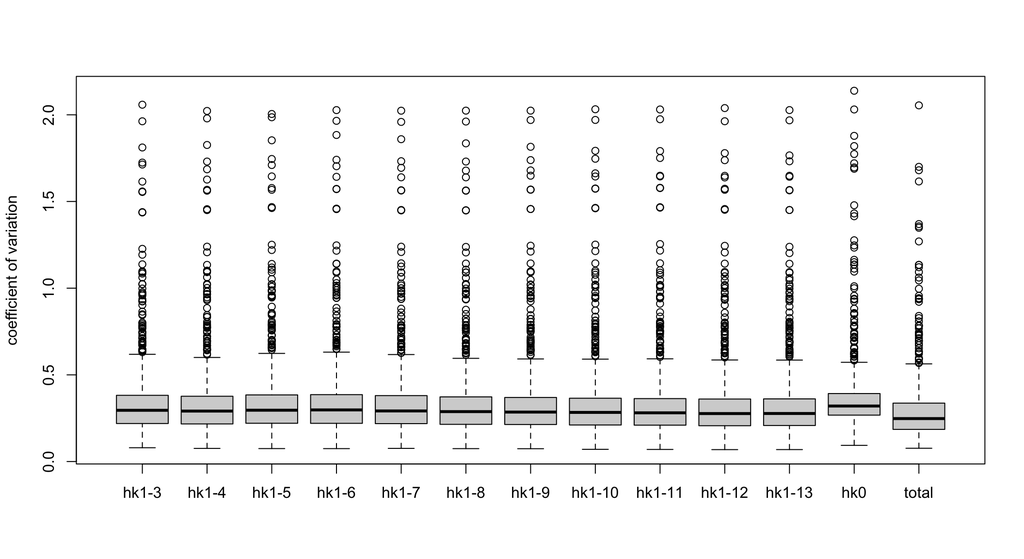

```r
cvList <- list()
for(i in 3 : 13){
  genes <- as.character(res.BM$ranking[1:i])

  ## House-keeping normalization factor
  hkNF <- dataNorm3 %>%
  filter(Name %in% genes) %>%
  group_by(Sample.x) %>% dplyr::summarise(hkGeoMean = geometric.mean(posNorm)) %>%
  mutate(hkNF = mean(hkGeoMean)/hkGeoMean)

  ## normalize data
  hkNorm <- full_join(dataNorm3, hkNF, by = "Sample.x") %>% mutate(hkNorm = posNorm*hkNF)

  ## calculate CVs
  cvDat <- hkNorm %>% filter(CodeClass == "Endogenous_Code_Summary") %>%
    group_by(Name) %>% dplyr::summarise(cv = sd(hkNorm)/mean(hkNorm))
  cv <- cvDat$cv
  names(cv) <- cvDat$Name
  cvList[[i-2]] <- cv
}
names(cvList) <- paste0("hk", "1-", 3:13)

## cvs of raw data
## calculate CVs
cvDat <- dataNorm3 %>% filter(CodeClass == "Endogenous_Code_Summary") %>%
    group_by(Name) %>% dplyr::summarise(cv = sd(posNorm)/mean(posNorm))
cv <- cvDat$cv
names(cv) <- cvDat$Name
cvList$`hk0` <- cv

## total sum normalization
## total sum normalization factor
totalNF <- dataNormEndoFiltered %>%
  group_by(Sample.x) %>% dplyr::summarise(totalsumMean = sum(posNorm)) %>%
  mutate(totalsumNF = mean(totalsumMean)/totalsumMean)
## normalize data
totalNorm <- full_join(dataNormEndoFiltered, totalNF, by = "Sample.x") %>% mutate(totalNorm = posNorm*totalsumNF)
## calculate CVs
cvDat <- totalNorm %>% filter(CodeClass == "Endogenous_Code_Summary") %>%
    group_by(Name) %>% dplyr::summarise(cv = sd(totalNorm)/mean(totalNorm))
cv <- cvDat$cv
names(cv) <- cvDat$Name
cvList$`total` <- cv

## boxplot of CVs for various normalizations
boxplot(do.call(cbind, cvList), ylab = "coefficient of variation")
```

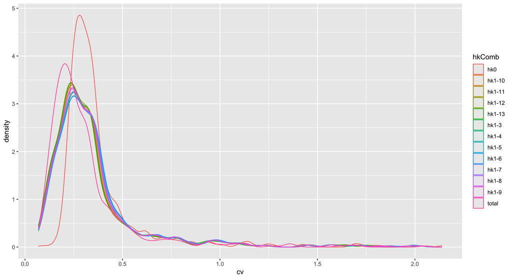

```r
## histogram of CVs for various normalizations
do.call(cbind, cvList) %>% as.data.frame %>% gather(hkComb, cv) %>%
  ggplot(aes(x = cv, color = hkComb)) + geom_density(alpha = 0.5)
```

## 3f. log2 transform total Norm data

```r
genEset0 <- totalNorm %>% filter(CodeClass == "Endogenous_Code_Summary") %>% dplyr::select(Sample.x, Name, totalNorm) %>%
        spread(Sample.x, totalNorm)
genEset <- log2(as.matrix(genEset0[, -1]))
genEset[genEset < 0] <- 0
rownames(genEset) <- genEset0$Name

demoPre <- demoPre[colnames(genEset), ]
all(demoPre$EorV_number == colnames(genEset))
```

```
## [1] TRUE
```

# 4) Gene Annotation

```r
ann0 <- read.csv(here::here("data", "geneAnnotations", "Cells_nCounter_Human_PanCancer_Immune_Profiling_Panel_Gene_List.csv"), row.names = 1)
table(ann0$Gene.Class)
```

```
##
##                                        CT Antigen
##                                                30
##                                                HK
##                                                40
##                                   Immune Response
##                                               582
##              Immune Response - Cell Type specific
##                                               105
## Immune Response - Cell Type specific / Checkpoint
##                                                 4
##                      Immune Response - Checkpoint
##                                                 9
```

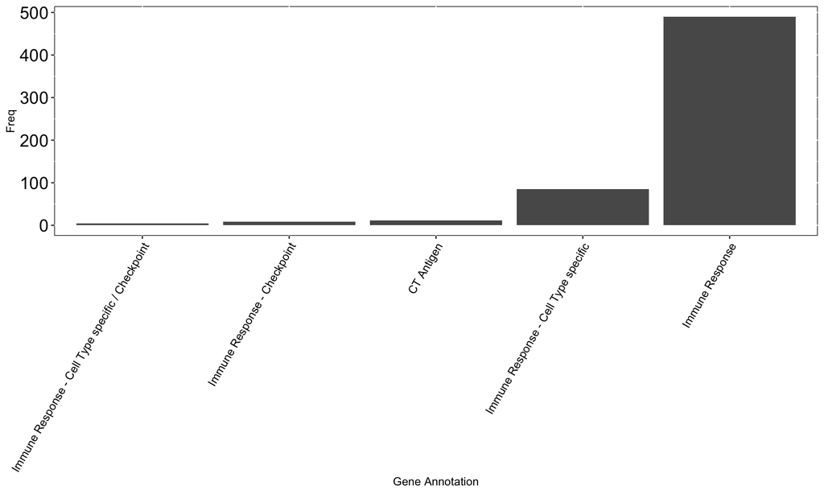

Gene Annotations

```r
ann <- ann0[rownames(genEset), ]

## plot total number of genes
table(ann$Gene.Class)[order(table(ann$Gene.Class))] %>%
  as.data.frame %>%
  ggplot(aes(x = Var1, y = Freq)) + geom_bar(stat = "identity") +
  customTheme(sizeStripFont = 10, xAngle = 60, hjust = 1, vjust = 1, xSize = 10,
    ySize = 15, xAxisSize = 10, yAxisSize = 10) + xlab("Gene Annotation")
```

```r
annCellType <- subset(ann, Gene.Class == "Immune Response - Cell Type specific")
```

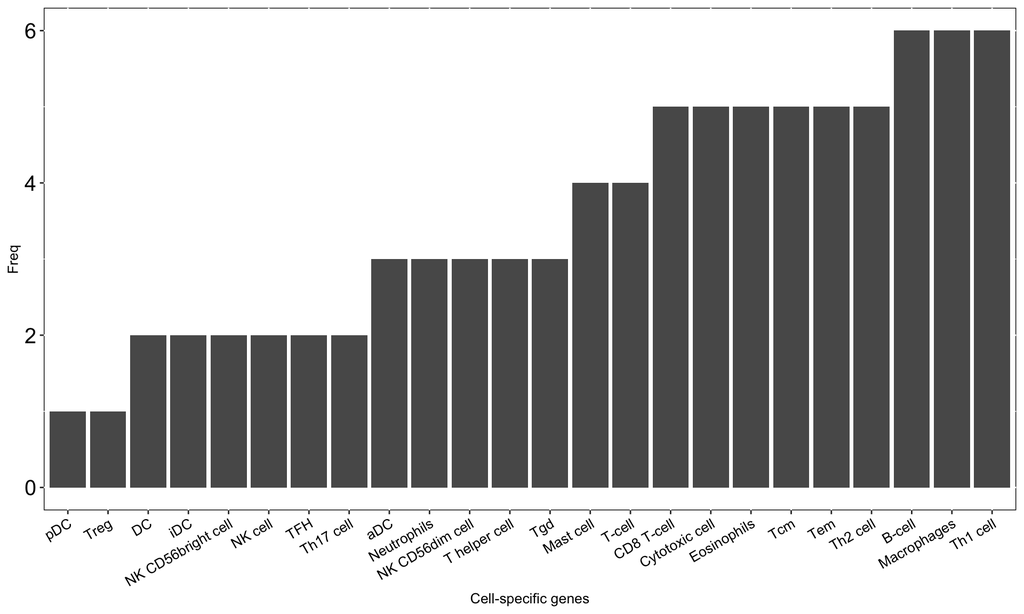

Cell-specific genes

```r
## plot break-down of cell-specific genes
table(annCellType$Cell.Type)[order(table(annCellType$Cell.Type))] %>%
  as.data.frame %>%
  ggplot(aes(x = Var1, y = Freq)) + geom_bar(stat = "identity") +
  customTheme(sizeStripFont = 10, xAngle = 30, hjust = 1, vjust = 1, xSize = 10,
    ySize = 15, xAxisSize = 10, yAxisSize = 10) + xlab("Cell-specific genes")
```

```r
annCT <- subset(ann, Gene.Class == "CT Antigen")
annImmRes <- subset(ann, !(Gene.Class %in% c("Immune Response - Cell Type specific", "CT Antigen", "HK")))

## gene set of annotations
imm <- strsplit(gsub(", ", ",", as.character(ann$Annotation)), ",")
names(imm) <- rownames(ann)
dfAnn <- data.frame(GeneName = rep(names(imm), unlist(lapply(imm, length))),
                       Pathway = unlist(imm))

## gene set of immune responses
immRes <- strsplit(gsub(", ", ",", as.character(annImmRes$Annotation)), ",")
names(immRes) <- rownames(annImmRes)
dfImmRes <- data.frame(GeneName = rep(names(immRes), unlist(lapply(immRes, length))),
                       Pathway = unlist(immRes))
dim(dfAnn); dim(dfImmRes);
```

```
## [1] 1254    2
```

```
## [1] 978   2
```

# 5) write out datasets

```r
save(demoPre=demoPre, genEset=genEset,
  ann=ann, dfAnn=dfAnn, dfImmRes=dfImmRes,
  file = here::here("data", "preprocessedData", "panCancerDatasets.RDATA"))
```